# Deep Learning Model vs Production Model for Manuscript Matcher

Joel Carlson

May 10, 2017

# Assessing replacement model vs production model

The old algorithm does not necessarily provide 10 predictions per request. Therefore, to do an “apples to apples” comparison, we need the number of predictions of each algorithm to be equal. That is, if production only gave two recommendations, we only take two of mine. When comparing the algorithms in this way, the results are as follows (code/data available):

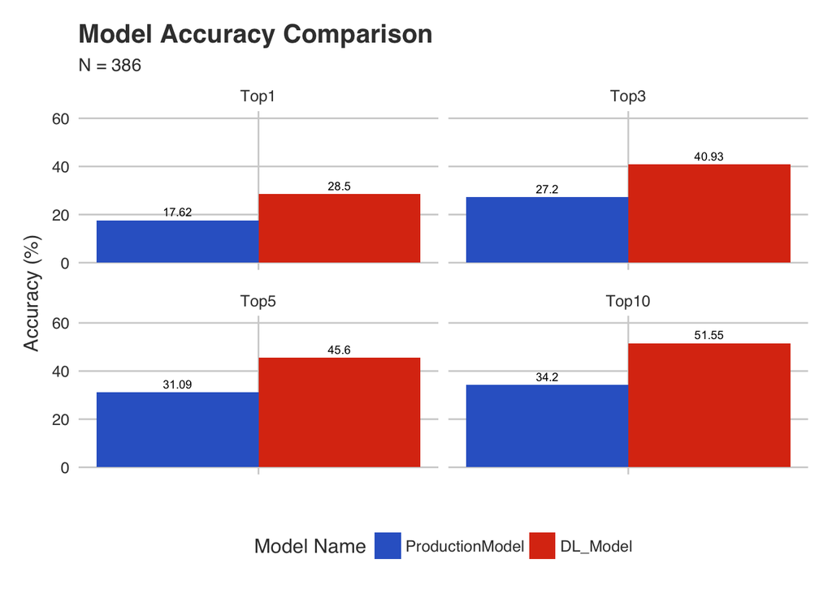

I recognize that these numbers are not the same as the previously reported numbers (all are lower). The reason for this is due to the way I handled the previous algorithm not always outputting X predictions. For example, for some requests they may only provide 2 recommendations, while for others they may provide up to 10.

For the current numbers, I have clipped our predictions to be of the same number as the number provided by the production algorithm, whereas the previous numbers I always provided 10 predictions. Furthermore, in the current version I always divide by the total number of observations in the data, whereas before I was dividing by only number of observations that had X or more predictions. The previous version was overly accomodating to both algorithms.

The current numbers are believed to be a better representation of the true reality of the results.